# 3주차 패키지

```r
setwd('C:/Users/ConditionKim/Desktop/P-SAT/패키지/3주차 패키지')
library(tidyverse)
library(data.table)
library(magrittr)
```

# 추가 챕터 1 - 인코딩

## 추가 문제 1

```r
train <- fread('데이터 0-1.csv', header = T, stringsAsFactors = F, data.table = F)
test <- fread('데이터 0-2.csv', header = T, stringsAsFactors = F, data.table = F)
```

## 추가 문제 2

```r
model_1 <- lm(Sepal.Length ~., data = train)
predict_1 <- predict(model_1, newdata = select(test, -Sepal.Length))
result_1 <- MLmetrics::RMSE(predict_1, test$Sepal.Length) ; result_1 # 0.3821226
```

```
## [1] 0.3821226
```

## 추가 문제 3

```r
library(dummies)
train_dummy <- dummy.data.frame(train, dummy.classes = 'character')
test_dummy <- dummy.data.frame(test, dummy.classes = 'character')
```

```r
model_2 <- lm(Sepal.Length~., data = train_dummy)
predict_2 <- predict(model_2, newdata = select(test_dummy, -Sepal.Length)) #warning
result_2 <- MLmetrics::RMSE(predict_2, test$Sepal.Length) ; result_2 # 0.3821226
```

```
## [1] 0.3821226
```

```r
length(model_2$coefficients) > model_2$rank
```

```
## [1] TRUE
```

```r
# 7 > 6; if the rank of your data matrix is at least equal to the number of parameters you want to fit.
rm(list = c('train_dummy', 'test_dummy'))
```

### rank 문제로 waring이 뜬다

## 추가 문제 4

```r
library(cattonum)
train_freq <- catto_freq(train = train, test = test)[[1]]
test_freq <- catto_freq(train = train, test = test)[[2]]

train$Species %>% table()
```

```
## .
##     setosa versicolor  virginica
##         45         45         45
```

```r
train_freq$Species %>% table()
```

```
## .
##  45
## 135
```

```r
test$Species %>% table()
```

```
## .
##     setosa versicolor  virginica
##          5          5          5
```

```r
test_freq$Species %>% table()
```

```
## .
## 45
## 15
```

```r
model_3 <- lm(Sepal.Length~., data = train_freq)
predict_3 <- predict(model_3, newdata = select(test_freq, -Sepal.Length)) # warning
result_3 <- MLmetrics::RMSE(predict_3, test_freq$Sepal.Length) ; result_3 # 0.3971448
```

```
## [1] 0.3971448
```

```r
length(model_3$coefficients) > model_3$rank # 5 > 4
```

```
## [1] TRUE
```

```r
rm(list = c('train_freq', 'test_freq'))
```

### rank 문제로 waring이 뜬다

## 추가 문제 5

```r
train_mean <- catto_mean(train = train,  response = Sepal.Length, test = test)[[1]]
test_mean <- catto_mean(train = train,  response = Sepal.Length ,test = test)[[2]]

model_4 <- lm(Sepal.Length~., data = train_mean)
predict_4 <- predict(model_4, newdata = select(test_mean, -Sepal.Length))
result_4 <- MLmetrics::RMSE(predict_4, test_mean$Sepal.Length) ; result_4 # 0.3909349
```

```
## [1] 0.3909349
```

```r
rm(list = c('train_mean', 'test_mean'))
```

## 추가 문제 6

```r
train_loo <- catto_loo(train = train, response = Sepal.Length, test = test)[[1]]
test_loo <- catto_loo(train = train, response = Sepal.Length, test = test)[[2]]

model_5 <- lm(Sepal.Length~., data = train_loo)
predict_5 <- predict(model_5, newdata = select(test_loo, -Sepal.Length))
result_5 <- MLmetrics::RMSE(predict_5, test_loo$Sepal.Length) ; result_5 # 0.3904023
```

```
## [1] 0.3904023
```

```r
rm(list = c('train_loo', 'test_loo'))
```

## 추가 문제 6-1

### mean encoding : 자신(행)까지 포함해서 y 변수에 대해 mean encoding

### leave_one_out encoding : 해당 행을 제외 하고 평균을 구함, outlier 영향을 줄임

### 동일하게 차원을 늘리지않는 장점이 있지만 mean encoding 은 과적합 되기 쉽다

### leave one out encoding은 direct response leakage를 방지할수있다(과적합 방지)

### direct response leakage(data leakage) : y변수가 train feature에 들어가는 문제(오버피팅 야기)

## 추가 문제 7

```r
do_cat_order_slow <- function(data, x, y, seed, replace) {

  set.seed(seed)

  data_save <- data[sample(nrow(data)), ] %>% as.data.frame()

  data_save[, x] %<>% as.character()

  start1 <- NULL

  for (i in data_save[, x] %>% unique()) {

    start1[i] <- which(data_save[, x] == i) %>% min()

  }; rm(i)

  start2 <- data_save %>%
    group_by(get(x)) %>%
    dplyr::summarize(encoding = mean(get(y))) %>%
    ungroup; colnames(start2)[1] <- x

  for (i in 1:nrow(data_save)) {

    if (i %in% start1) {

      encoding1 <- start2[start2[, x] == data_save[i, x], ]

      data_save$encoding[i] <- encoding1$encoding

    } else {

      encoding2 <- data_save[1:(i-1), ] %>%
        group_by(get(x)) %>%
        dplyr::summarize(encoding = mean(get(y))) %>%
        ungroup; colnames(encoding2)[1] <- x

        encoding2 <- encoding2[encoding2[, x] == data_save[i, x], ]

        data_save$encoding[i] <- encoding2$encoding

    }

    print(i)

  }; rm(encoding1, encoding2, start1, start2)

  if (replace == T) {

    data_save[x] <- NULL
    colnames(data_save)[ncol(data_save)] <- x

  } else {

    colnames(data_save)[ncol(data_save)] <- paste0(x, "_order")

  }

  data_save$row <- rownames(data_save) %>% as.numeric

  data_save %<>% arrange(row) %>% select(-row)

  return(data_save)

}
```

### mean encoding data leakage 를 막기 위해, 현재 데이터의 타겟 값은 사용하지 않고, 이전 것만 사용

### leave one out과 다른 점 : 현재 데이터 빼고 다쓰는 것이 아닌, 이전 데이터만 사용

```r
train_order_target <- do_cat_order_slow(train, 'Species', 'Sepal.Length', 1, T)
```

```
## [1] 1
## [1] 2
## [1] 3
## [1] 4
## [1] 5
## [1] 6
## [1] 7
## [1] 8
## [1] 9
## [1] 10
## [1] 11
## [1] 12
## [1] 13
## [1] 14
## [1] 15
```

[output cut: 120 more lines]

```r
test_order_target <- do_cat_order_slow(test, 'Species', 'Sepal.Length', 1, T)
```

```
## [1] 1
## [1] 2
## [1] 3
## [1] 4
## [1] 5
## [1] 6
## [1] 7
## [1] 8
## [1] 9
## [1] 10
## [1] 11
## [1] 12
## [1] 13
## [1] 14
## [1] 15
```

```r
model_6 <- lm(Sepal.Length~., data = train_order_target)
predict_6 <- predict(model_6, newdata = select(test_order_target, -Sepal.Length))
result_6 <- MLmetrics::RMSE(predict_6, test_order_target$Sepal.Length) ; result_6 # 0.4089973
```

```
## [1] 0.4089973
```

```r
rm(list = c('train_order_target', 'test_order_target', 'do_cat_order_slow'))
```

## 추가 문제 8

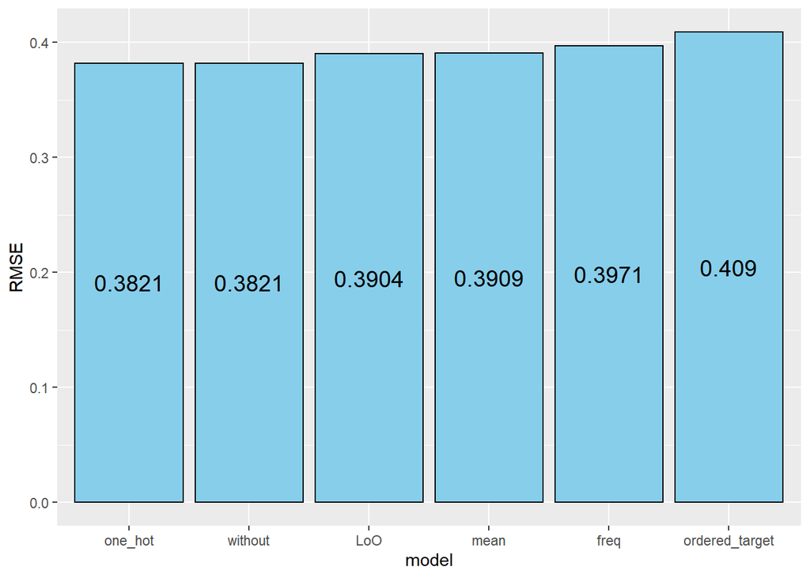

```r
model_RMSE <- data.frame('model' = c('without', 'one_hot', 'freq',
                                     'mean', 'LoO', 'ordered_target'),
                         'RMSE' = c(result_1, result_2, result_3, result_4, result_5, result_6))

model_RMSE %>% ggplot(aes(reorder(model, RMSE), y = RMSE)) +
  geom_col(color = 'black', fill = 'skyblue') +
  geom_text(aes(label=round(RMSE, 4)), position = position_stack(0.5), size = 5) +
  labs(x = 'model', y = 'RMSE')
```

## 추가 문제 8-1

### 같음 lm도 범주형 변수에 대해 one hot encoding 방식으로 진행한다

### 다만 one hot encoding은 j개의 범주에대해 j개의 변수를 lm은 자동적으로 j-1개의 가변수를 만든다

## 추가 문제 8-2

### one hot encoding, with out encoding : 순서 개념이 없는 범주 변수의 특징을 가지고 있음 -> 제일 best

```r
train_freq <- catto_freq(train = train, test = test)[[1]]
test_freq <- catto_freq(train = train, test = test)[[2]]

train$Species %>% table()
```

```
## .
##     setosa versicolor  virginica
##         45         45         45
```

```r
train_freq$Species %>% table()
```

```
## .
##  45
## 135
```

```r
test_freq$Species %>% table()
```

```
## .
## 45
## 15
```

### freq encoding : 범주 빈도수가 같아서 의미 x

### 다른 encoding : target encoding -> 아무래도 한 Feature 내에 피처 값들을 Numeric 형태로 Encoding 하다보니,

### Categorical 값들은 순서개념이 없음에도, 모델은 순서개념을 전제하여 학습하게 된다.

### (이는 Numeric 형태의 어쩔 수 없는 특성임…)

### 위와 같은 이유로 Linear Regression 모델에 적합한 방법은 아니다.

## 추가 문제 8-3

### 다른 encoding : target encoding -> 아무래도 한 Feature 내에 피처 값들을 Numeric 형태로 Encoding 하다보니,

### Categorical 값들은 순서개념이 없음에도, 모델은 순서개념을 전제하여 학습하게 된다.

### (이는 Numeric 형태의 어쩔 수 없는 특성임…)

### 위와 같은 이유로 Linear Regression 모델에 적합한 방법은 아니다.

### 하지만, 변수 수가 늘어나지 않는다는 점에서, 범주 level이 너무 많다면 추천

## 지우고 합시다

```r
rm(list = ls())
```

# 챕터 2 병렬화

## 문제 1

```r
library(tictoc)
tic(); Sys.sleep(3); toc()
```

```
## 3.03 sec elapsed
```

```r
start <- Sys.time(); Sys.sleep(3); end <- Sys.time(); end - start
```

```
## Time difference of 3.005535 secs
```

```r
rm(list = c('start', 'end'))
```

## 문제 2

```r
library(foreach)
data1 <- NULL
tic() ; start = Sys.time()
for (i in 1:10) {
  data1 <- cbind(data1, rnorm(5000 * 2000))
  print(i)
}; rm(i); toc() ; end = Sys.time() ; for_time = end - start
```

```
## [1] 1
## [1] 2
## [1] 3
## [1] 4
## [1] 5
## [1] 6
## [1] 7
## [1] 8
## [1] 9
## [1] 10
```

```
## 6.75 sec elapsed
```

```r
for_time
```

```
## Time difference of 6.75548 secs
```

```r
data1 <- NULL
tic() ; start = Sys.time()
foreach(i = 1:10, .verbose = F)%do%{
  data1 <- cbind(data1, rnorm(5000 * 2000))
  print(i)
}; rm(i); toc() ; end = Sys.time() ; foreach_do_time = end - start
```

```
## [1] 1
## [1] 2
## [1] 3
## [1] 4
## [1] 5
## [1] 6
## [1] 7
## [1] 8
## [1] 9
## [1] 10
```

```
## [[1]]
## [1] 1
##
## [[2]]
## [1] 2
##
## [[3]]
## [1] 3
##
## [[4]]
## [1] 4
##
## [[5]]
## [1] 5
##
## [[6]]
## [1] 6
##
## [[7]]
## [1] 7
##
## [[8]]
## [1] 8
##
## [[9]]
## [1] 9
##
## [[10]]
## [1] 10
```

```
## 6.06 sec elapsed
```

```r
for_time ; foreach_do_time
```

```
## Time difference of 6.75548 secs
```

```
## Time difference of 6.058016 secs
```

## 문제 3

```r
library(doParallel)
cl <- makeCluster(detectCores() - 1)
registerDoParallel(cl)

data1 <- NULL
tic() ; start = Sys.time()
foreach(i = 1:10, .verbose = F)%dopar%{
  data1 <- cbind(data1, rnorm(5000 * 2000))
  print(i)
} ;toc() ; end = Sys.time() ; foreach_dopar_time = end - start
```

```
## [[1]]
## [1] 1
##
## [[2]]
## [1] 2
##
## [[3]]
## [1] 3
##
## [[4]]
## [1] 4
##
## [[5]]
## [1] 5
##
## [[6]]
## [1] 6
##
## [[7]]
## [1] 7
##
## [[8]]
## [1] 8
##
## [[9]]
## [1] 9
##
## [[10]]
## [1] 10
```

```
## 1.58 sec elapsed
```

```r
stopCluster(cl)

rm(list = c('cl', 'data1', 'end', 'start'))
```

## 문제 3-1

```r
cl <- makeCluster(detectCores() - 1)
registerDoParallel(cl)

data1 <- NULL

f <- function(){
  pb <- txtProgressBar(min=1, max=9,style=3)
  count <- 0
  function(...) {
    count <<- count + length(list(...)) - 1
    setTxtProgressBar(pb,count)
    Sys.sleep(0.01)
    flush.console()
    c(...)
  }
}

foreach(i = 1:10, .verbose = F, .combine = f())%dopar%{
  data1 <- cbind(data1, rnorm(5000 * 2000))
}
```

[output not shown]

[output cut: 19986 more lines]

```r
stopCluster(cl)
```

## 문제 4

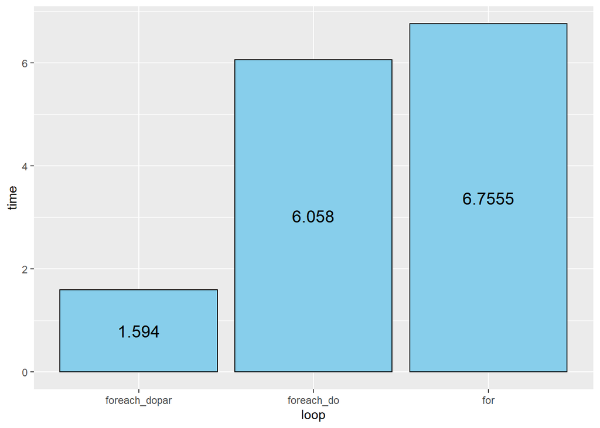

```r
time_check <- tibble('loop' = c('for', 'foreach_do', 'foreach_dopar'),
                     'time' = c(as.numeric(for_time), as.numeric(foreach_do_time), as.numeric(foreach_dopar_time)))

time_check %>% ggplot(aes(x = reorder(loop, time), y = time)) +
  geom_col(color = 'black', fill = 'skyblue') +
  geom_text(aes(label=round(time, 4)), position = position_stack(0.5), size = 5) +
  labs(x = 'loop', y = 'time')
```

### 병렬 처리 했을 때 속도가 가장 빠르다. 10번 도는 loop를 할당한 코어 만큼 나눠서 하기 때문. 기본 R 할당 코어는 1개다

## 문제 5

```r
rm(list = ls())
setwd('C:/Users/ConditionKim/Desktop/P-SAT/패키지/3주차 패키지/데이터 2')

cl <- makeCluster(detectCores() - 1)
registerDoParallel(cl)

data_train <- foreach(i = 1:99,
                      .verbose = F,
                      .combine = 'rbind',
                      .packages = c('data.table', 'tidyverse'))%dopar%{
  fread(paste0('데이터 2 ',i, '.csv'), header = T, stringsAsFactors = F, data.table = F)
                      }

stopCluster(cl)
data_train %>% glimpse()
```

```
## Observations: 19,742
## Variables: 23
## $ click                  <int> 0, 0, 0, 0, 0, 0, 0, 0, 0, 0, 0, 0, 0, 0, 0,...
## $ ssp_id                 <chr> "nwf1A3O5cO", "M6QaRvdZ8h", "SrN77Arvqh", "n...
## $ placement_type         <chr> "kIeE1J0KCa", "kIeE1J0KCa", "1pcQ3RJgQt", "k...
## $ device_connection_type <chr> "aEmZFzgDfq", "aEmZFzgDfq", "Hx7e3tE5mu", "W...
## $ device_language        <chr> "LXYiFbLmMp", "LXYiFbLmMp", "8GSkINt29e", "L...
## $ advertisement_id       <chr> "kZP6ssxfMO", "kZP6ssxfMO", "7dyzy9aZoJ", "k...
## $ weekend                <chr> "wd", "wd", "wd", "wd", "wd", "wd", "wd", "w...
## $ hour                   <chr> "X0", "X0", "X0", "X0", "X0", "X0", "X0", "X...
## $ min60                  <dbl> 0.1041185, 0.1041185, 0.1041185, 0.1041185, ...
## $ min30                  <dbl> 0.1050248, 0.1050248, 0.1050248, 0.1050248, ...
## $ min20                  <dbl> 0.1059237, 0.1059237, 0.1059237, 0.1059237, ...
## $ min10                  <dbl> 0.1094316, 0.1094316, 0.1094316, 0.1094316, ...
## $ min5                   <dbl> 0.1125000, 0.1125000, 0.1125000, 0.1125000, ...
## $ min1                   <dbl> 0.10248447, 0.10248447, 0.13521127, 0.135211...
## $ age                    <chr> "c", "c", "f", "e", "h", "g", "g", "f", "h",...
## $ gender                 <chr> "F", "F", "M", "F", "F", "M", "M", "F", "M",...
## $ marry                  <chr> "S", "M", "S", "M", "M", "S", "S", "S", "M",...
## $ install_pack_num       <int> 84, 50, 59, 218, 145, 78, 90, 54, 117, 143, ...
## $ cat1                   <int> 11, 12, 5, 28, 13, 9, 10, 9, 14, 16, 3, 10, ...
## $ cat2                   <int> 10, 5, 9, 15, 14, 14, 11, 8, 11, 21, 19, 18,...
## $ cat3                   <int> 7, 4, 8, 15, 12, 6, 17, 3, 14, 16, 16, 17, 1...
## $ cat4                   <int> 6, 8, 10, 9, 10, 7, 4, 3, 12, 14, 15, 21, 4,...
## $ cat5                   <int> 3, 2, 6, 15, 14, 3, 10, 2, 2, 5, 5, 15, 8, 6...
```

```r
rm(cl)
```

## 문제 6

```r
setwd('C:/Users/ConditionKim/Desktop/P-SAT/패키지/3주차 패키지')
data_test <- fread("데이터 1.csv", stringsAsFactors = F)

data_train %<>% mutate_if(is.character, as.factor)
data_test %<>% mutate_if(is.character, as.factor)

data_test <- rbind(data_train[1, ], data_test)
data_test <- data_test[-1, ]

data_train <- rbind(data_test[1, ], data_train)
data_train <- data_train[-1, ]

data_train$click %<>% as.character %>% as.factor
data_test$click %<>% as.character %>% as.factor
```

## 문제 7

```r
library(randomForest)
tic() ; start = Sys.time()
set.seed(1)
model_rf_1 <- randomForest(click~., data_train, ntree = 500, importance = T)
toc() ; end = Sys.time() ; rf_1_time = end - start
```

```
## 37.91 sec elapsed
```

## 문제 8

```r
detectCores()
```

```
## [1] 8
```

```r
core_num <- detectCores() - 1
cl <- makeCluster(detectCores() - 1)
registerDoParallel(cl)

tic() ; start = Sys.time()
model_rf_2 <- foreach(ntree = c(rep(ceiling(500/7), 6), ceiling(500/7) - 4),
                      .combine = combine,
                      .verbose = F,
                      .multicombine=T,
                      .packages = "randomForest")%dopar%{
                        set.seed(1)
                        randomForest(click~.,data_train, ntree=ntree, importance = T)
                        }; toc() ; end = Sys.time() ; rf_2_time = end - start
```

```
## 11.56 sec elapsed
```

```r
stopCluster(cl)
rm(cl)
```

## 문제 9

```r
library(MLmetrics)
real_click <- as.numeric(data_test$click) - 1

predict_rf_1 <- predict(model_rf_1, newdata = select(data_test,-click), type = 'prob')[,2]
result_rf_1 <- LogLoss(predict_rf_1,real_click) ; result_rf_1
```

```
## [1] 0.2865517
```

```r
predict_rf_2 <- predict(model_rf_2, newdata = select(data_test,-click), type = 'prob')[,2]
result_rf_2 <- LogLoss(predict_rf_2,real_click) ; result_rf_2
```

```
## [1] 0.2910159
```

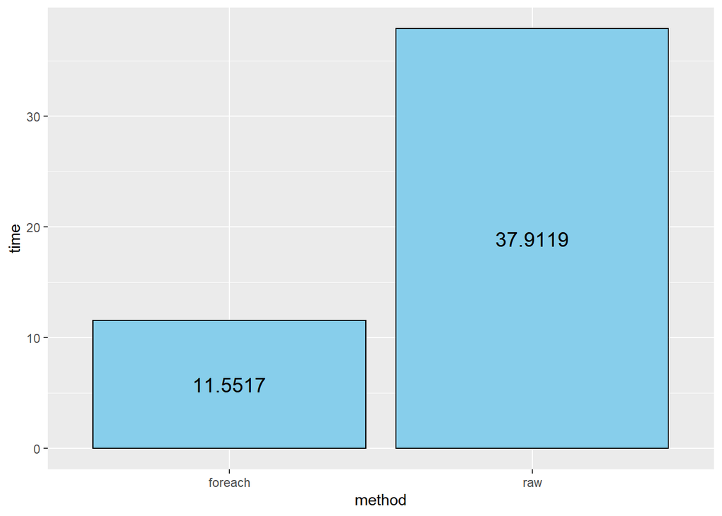

```r
time_check <- tibble('method' = c('raw', 'foreach'),
                     'time' = c(as.numeric(rf_1_time), as.numeric(rf_2_time)))

time_check %>% ggplot(aes(x = reorder(method, time), y = time)) +
  geom_col(color = 'black', fill = 'skyblue') +
  geom_text(aes(label=round(time, 4)), position = position_stack(0.5), size = 5) +
  labs(x = 'method', y = 'time')
```

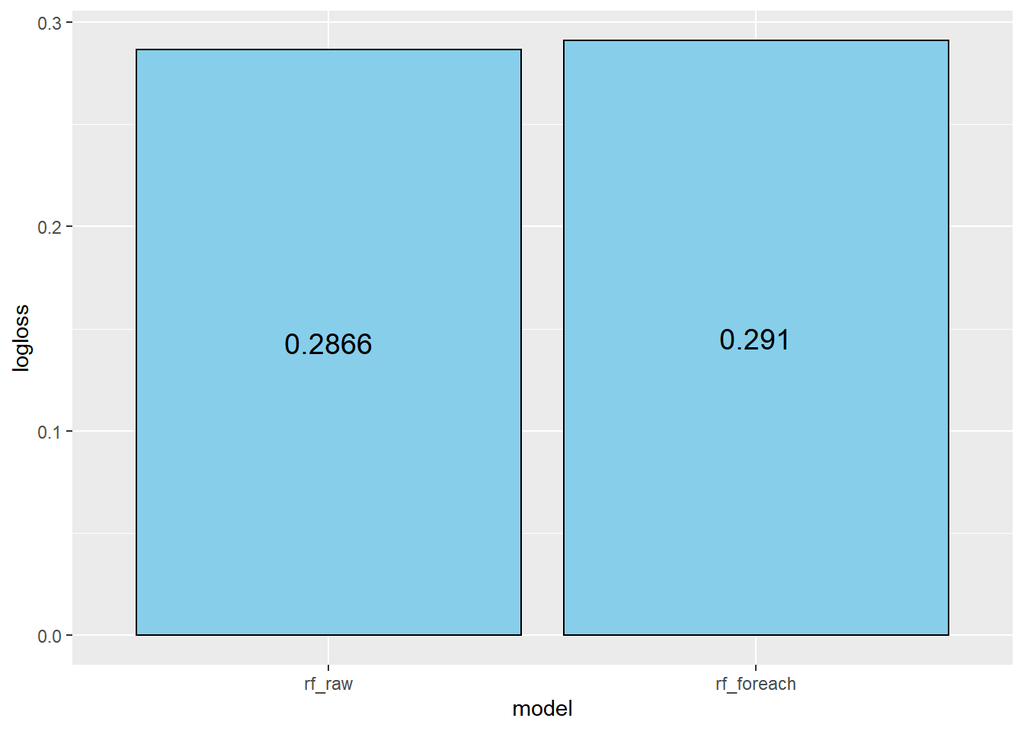

```r
result <- tibble('model' = c('rf_raw', 'rf_foreach'),
                 'logloss' = c(result_rf_1, result_rf_2))

result %>% ggplot(aes(x = reorder(model, logloss), y = logloss)) +
  geom_col(color = 'black', fill = 'skyblue') +
  geom_text(aes(label = round(logloss, 4)), position = position_stack(0.5), size = 5) +
  labs(x = 'model', y = 'logloss')
```

### 병렬로 모델링 진행했을 때, 속도가 현저히 빨라졌다

### 모델 성능은 안 좋게 나왔다. 이유는 모르겠당 헤헤

## 추가 문제 10

```r
detectCores()
```

```
## [1] 8
```

```r
core_num <- detectCores() - 1
cl <- makeCluster(detectCores() - 1)
registerDoParallel(cl)

tic() ; start = Sys.time()
model_rf_3 <- foreach(ntree = c(rep(ceiling(500/7), 6), ceiling(500/7) - 4),
                      i = 1 : core_num,
                      .combine = combine,
                      .verbose = F,
                      .multicombine=T,
                      .packages = "randomForest")%dopar%{
                        set.seed(i)
                        randomForest(click~.,data_train, ntree=ntree, importance = T)
                      }; toc() ; end = Sys.time() ; rf_3_time = end - start
```

```
## 11.55 sec elapsed
```

```r
stopCluster(cl)
rm(cl)

predict_rf_3 <- predict(model_rf_3, newdata = select(data_test,-click), type = 'prob')[,2]
result_rf_3 <- LogLoss(predict_rf_3,real_click) ; result_rf_3
```

```
## [1] 0.2761077
```

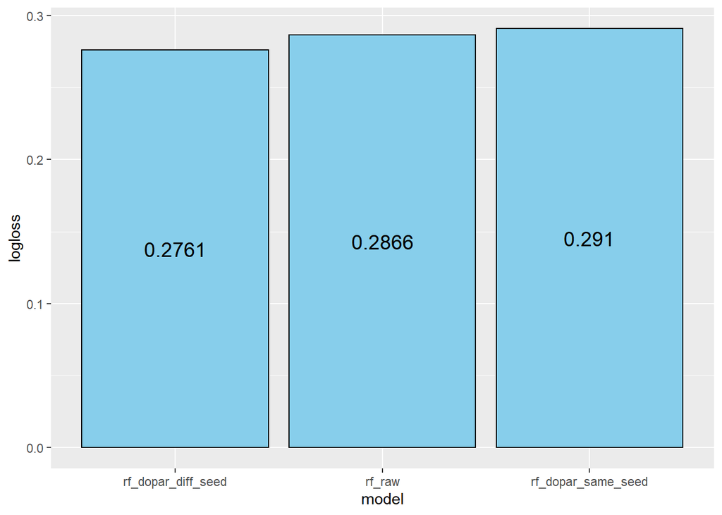

```r
result <- tibble('model' = c('rf_raw', 'rf_dopar_same_seed', 'rf_dopar_diff_seed'),
                 'logloss' = c(result_rf_1, result_rf_2, result_rf_3))

result %>% ggplot(aes(x = reorder(model, logloss), y = logloss)) +
  geom_col(color = 'black', fill = 'skyblue') +
  geom_text(aes(label = round(logloss, 4)), position = position_stack(0.5), size = 5) +
  labs(x = 'model', y = 'logloss')
```

### 시드를 다르게 해주었더니 좋아졌다!!

### 1이 best seed가 아니었을 수 있다

### 실제 seed 따라 성능이 달라진다

## 지우고 합시다~

```r
rm(list = ls()[which(!ls() %in% c('data_train', 'data_test'))])
```

# 챕터 3 - 캣부스트 모델

## 문제 1

```r
data_train = data_train %>% mutate(click = as.numeric(click)-1)
data_test = data_test %>% mutate(click = as.numeric(click)-1)
data_train$click %>% str()
```

```
##  num [1:19742] 0 0 0 0 0 0 0 0 0 0 ...
```

```r
data_test$click %>% str()
```

```
##  num [1:2552] 0 0 0 0 0 1 0 0 0 0 ...
```

## 문제 2

```r
library(catboost)
```

### 이미 있당 헤헤

### catboost 를 깔기 위해서 devtools가 필요하다

### devtools 는 R 버전 3.6.2 이상일 때 가능하니 R.version.string 함수로 버전 확인 후 업데이트하자

## 문제 3

```r
train_pool <- catboost.load_pool(data = select(data_train, - click),
                                 label = data_train$click)

test_pool <- catboost.load_pool(data = select(data_test, -click),
                                label = data_test$click)
train_pool ; test_pool
```

```
## catboost.Pool
## 19742 rows, 22 columns
```

```
## catboost.Pool
## 2552 rows, 22 columns
```

## 문제 4

```r
params <- list(
  loss_function = 'Logloss',
  random_seed = 1,
  logging_level = 'Verbose',
  train_dir = "CatBoost_output",
  iterations = 200,
  max_ctr_complexity = 4,
  bootstrap_type = 'Bayesian',
  learning_rate = 0.1,
  task_type = 'CPU'
)

start = Sys.time()
model_cb <- catboost.train(learn_pool = train_pool,
                           params = params); end = Sys.time() ; cb_cpu_time = end - start
```

```
## 0:   learn: 0.5853681    total: 121ms    remaining: 24.1s
## 1:   learn: 0.5154355    total: 189ms    remaining: 18.7s
## 2:   learn: 0.4630791    total: 205ms    remaining: 13.5s
## 3:   learn: 0.4145839    total: 239ms    remaining: 11.7s
## 4:   learn: 0.3844577    total: 297ms    remaining: 11.6s
## 5:   learn: 0.3611693    total: 357ms    remaining: 11.6s
## 6:   learn: 0.3426152    total: 406ms    remaining: 11.2s
## 7:   learn: 0.3285848    total: 458ms    remaining: 11s
## 8:   learn: 0.3180799    total: 474ms    remaining: 10.1s
## 9:   learn: 0.3051020    total: 511ms    remaining: 9.71s
## 10:  learn: 0.2937333    total: 551ms    remaining: 9.47s
## 11:  learn: 0.2856260    total: 604ms    remaining: 9.46s
## 12:  learn: 0.2786171    total: 656ms    remaining: 9.44s
## 13:  learn: 0.2741736    total: 702ms    remaining: 9.33s
## 14:  learn: 0.2699480    total: 745ms    remaining: 9.19s
```

[output cut: 185 more lines]

```r
predict_cb <- catboost.predict(model_cb, test_pool, prediction_type = 'Probability')
real_click <- data_test$click
result_cb <- LogLoss(predict_cb, real_click) ; result_cb
```

```
## [1] 0.2526795
```

## 문제 5

```r
cb_cv <- catboost.cv(train_pool,
                     params = params,
                     fold_count = 3,
                     partition_random_seed = 1,
                     stratified = T
)
```

```
## 0:   learn: 0.5991780    test: 0.5993661 best: 0.5993661 (0) total: 213ms    remaining: 42.4s
## 1:   learn: 0.5269007    test: 0.5273432 best: 0.5273432 (1) total: 444ms    remaining: 43.9s
## 2:   learn: 0.4681068    test: 0.4685349 best: 0.4685349 (2) total: 635ms    remaining: 41.7s
## 3:   learn: 0.4187448    test: 0.4189145 best: 0.4189145 (3) total: 820ms    remaining: 40.2s
## 4:   learn: 0.3874246    test: 0.3888090 best: 0.3888090 (4) total: 1.01s    remaining: 39.3s
## 5:   learn: 0.3623749    test: 0.3636403 best: 0.3636403 (5) total: 1.1s remaining: 35.5s
## 6:   learn: 0.3400163    test: 0.3411586 best: 0.3411586 (6) total: 1.21s    remaining: 33.3s
## 7:   learn: 0.3256869    test: 0.3268354 best: 0.3268354 (7) total: 1.37s    remaining: 32.9s
## 8:   learn: 0.3118513    test: 0.3130164 best: 0.3130164 (8) total: 1.57s    remaining: 33.4s
## 9:   learn: 0.3011088    test: 0.3024001 best: 0.3024001 (9) total: 1.69s    remaining: 32.1s
## 10:  learn: 0.2916696    test: 0.2932226 best: 0.2932226 (10)    total: 1.89s    remaining: 32.4s
## 11:  learn: 0.2837324    test: 0.2855146 best: 0.2855146 (11)    total: 2s   remaining: 31.3s
## 12:  learn: 0.2777613    test: 0.2794386 best: 0.2794386 (12)    total: 2.12s    remaining: 30.4s
## 13:  learn: 0.2732721    test: 0.2749078 best: 0.2749078 (13)    total: 2.26s    remaining: 30s
## 14:  learn: 0.2703268    test: 0.2719238 best: 0.2719238 (14)    total: 2.36s    remaining: 29.1s
```

[output cut: 185 more lines]

```r
cb_cv[which.min(cb_cv$test.Logloss.mean),]
```

```
##     test.Logloss.mean test.Logloss.std train.Logloss.mean train.Logloss.std
## 114         0.2511601     0.0006110004          0.2251169       0.001118307
```

## 다른 방법 - 그리드 서치

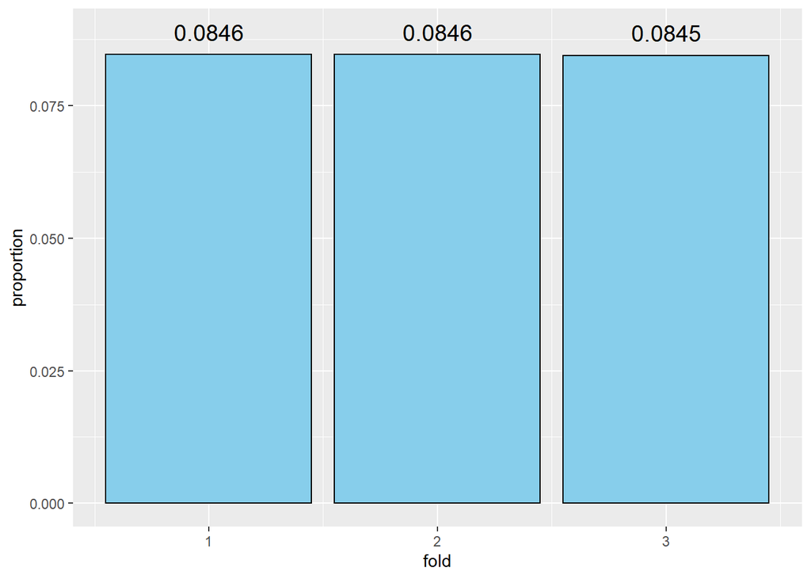

```r
set.seed(5252)
n_split <- 3
cv <- caret::createFolds(as.factor(data_train$click), k = n_split)

check <- NULL
for(i in 1 :3){
  result <- data_train[cv[[i]],]$click %>% mean()
  check <- c(check, result)

}
data.frame('fold' = 1:3, 'proportion' = check) %>% ggplot(aes(x = fold, y = proportion)) +
  geom_col(color = 'black', fill = 'skyblue') +
  geom_text(aes(label=round(proportion, 4)), position = position_stack(1.05), size = 5)
```

```r
cv_param <- expand.grid(loss_function = 'Logloss',
                        random_seed = 1,
                        logging_level = 'Silent',
                        train_dir = "CatBoost_output",
                        iterations = seq(100, 200, by = 50),
                        max_ctr_complexity = 4,
                        bootstrap_type = 'Bayesian',
                        learning_rate = 0.1,
                        task_type = 'CPU'
)

library(plyr)
progress.bar <- create_progress_bar("text")
progress.bar$init(nrow(cv_param))
param_result <- data.frame()

for(j in 1 : nrow(cv_param)){
  logloss_result = c()
  for(i in 1:n_split){
    print(paste0('cv_fold ', i, ' in ', j, ' loop'))
    idx = cv[[i]]
    train_set = data_train[-idx,]
    test_set = data_train[idx,]

    cv_train_pool = catboost.load_pool(data = select(train_set, -click),
                                       label = train_set$click)

    cv_test_pool = catboost.load_pool(data = select(test_set, -click),
                                      label = test_set$click)


    CatBoost_mod = catboost.train(learn_pool = cv_train_pool,
                                  params = as.list(cv_param[j,]))

    predict = catboost.predict(CatBoost_mod, cv_test_pool, prediction_type = 'Probability')

    logloss = LogLoss(predict, test_set$click)

    logloss_result = c(logloss_result, logloss)
  }
  cv_mean_logloss = mean(logloss_result)
  result = data.frame(cv_param[j,], 'cv_logloss' = cv_mean_logloss)
  param_result = rbind(param_result, result)
  progress.bar$step()
}
```

```
## [1] "cv_fold 1 in 1 loop"
## [1] "cv_fold 2 in 1 loop"
## [1] "cv_fold 3 in 1 loop"
##
## [1] "cv_fold 2 in 2 loop"
## [1] "cv_fold 3 in 2 loop"
##
## [1] "cv_fold 2 in 3 loop"
## [1] "cv_fold 3 in 3 loop"
##
```

```r
param_result[which.min(param_result$cv_logloss),]
```

```
##   loss_function random_seed logging_level       train_dir iterations
## 1       Logloss           1        Silent CatBoost_output        100
##   max_ctr_complexity bootstrap_type learning_rate task_type cv_logloss
## 1                  4       Bayesian           0.1       CPU  0.2514458
```

## 결과 비교

```r
best_param <- list(loss_function = 'Logloss',
                   random_seed = 1,
                   logging_level = 'Verbose',
                   train_dir = "CatBoost_output",
                   iterations = as.numeric(row.names(cb_cv[which.min(cb_cv$test.Logloss.mean),])),
                   max_ctr_complexity = 4,
                   bootstrap_type = 'Bayesian',
                   learning_rate = 0.1,
                   task_type = 'CPU'
                   )

model_cb_2 <- catboost.train(learn_pool = train_pool,
                             params = best_param)
```

```
## 0:   learn: 0.5853681    total: 62.7ms   remaining: 7.08s
## 1:   learn: 0.5154355    total: 123ms    remaining: 6.87s
## 2:   learn: 0.4630791    total: 151ms    remaining: 5.57s
## 3:   learn: 0.4145839    total: 177ms    remaining: 4.86s
## 4:   learn: 0.3844577    total: 234ms    remaining: 5.09s
## 5:   learn: 0.3611693    total: 278ms    remaining: 5s
## 6:   learn: 0.3426152    total: 377ms    remaining: 5.76s
## 7:   learn: 0.3285848    total: 445ms    remaining: 5.89s
## 8:   learn: 0.3180799    total: 464ms    remaining: 5.41s
## 9:   learn: 0.3051020    total: 502ms    remaining: 5.22s
## 10:  learn: 0.2937333    total: 540ms    remaining: 5.06s
## 11:  learn: 0.2856260    total: 583ms    remaining: 4.95s
## 12:  learn: 0.2786171    total: 630ms    remaining: 4.89s
## 13:  learn: 0.2741736    total: 669ms    remaining: 4.78s
## 14:  learn: 0.2699480    total: 710ms    remaining: 4.69s
```

[output cut: 99 more lines]

```r
predict_cb_2 <- catboost.predict(model_cb_2, test_pool, prediction_type = 'Probability')
result_cb_2 <- LogLoss(predict_cb_2, real_click) ; result_cb_2
```

```
## [1] 0.2513553
```

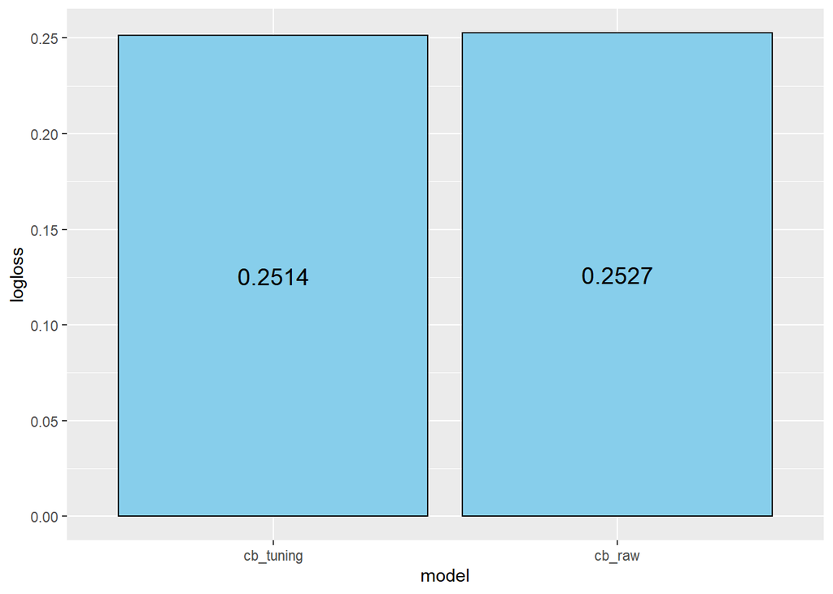

```r
result <- tibble('model' = c('cb_raw', 'cb_tuning'),
                 'logloss' = c(result_cb, result_cb_2))

result %>% ggplot(aes(x = reorder(model, logloss), y = logloss)) +
  geom_col(color = 'black', fill = 'skyblue') +
  geom_text(aes(label = round(logloss, 4)), position = position_stack(0.5), size = 5) +
  labs(x = 'model', y = 'logloss')
```

### best iteration 을 찾아줬을 때 logloss가 더 작게 나온다

### iteration이 끝까지 돌면서 overfitting이 일어나서 logloss가 높게 나왔다

## 번외 : catboost.train 에 test_pool 이라는 argument에 test값을 넣어준다

```r
model_cb_3 <- catboost.train(learn_pool = train_pool,
                             test_pool = test_pool,
                             params = params)
```

```
## 0:   learn: 0.5853681    test: 0.5876218 best: 0.5876218 (0) total: 64.4ms   remaining: 12.8s
## 1:   learn: 0.5154355    test: 0.5207601 best: 0.5207601 (1) total: 126ms    remaining: 12.5s
## 2:   learn: 0.4630791    test: 0.4685845 best: 0.4685845 (2) total: 170ms    remaining: 11.2s
## 3:   learn: 0.4145839    test: 0.4187947 best: 0.4187947 (3) total: 197ms    remaining: 9.67s
## 4:   learn: 0.3844577    test: 0.3889373 best: 0.3889373 (4) total: 267ms    remaining: 10.4s
## 5:   learn: 0.3611693    test: 0.3664531 best: 0.3664531 (5) total: 313ms    remaining: 10.1s
## 6:   learn: 0.3426152    test: 0.3485549 best: 0.3485549 (6) total: 366ms    remaining: 10.1s
## 7:   learn: 0.3285848    test: 0.3355289 best: 0.3355289 (7) total: 450ms    remaining: 10.8s
## 8:   learn: 0.3180799    test: 0.3252870 best: 0.3252870 (8) total: 488ms    remaining: 10.4s
## 9:   learn: 0.3051020    test: 0.3114495 best: 0.3114495 (9) total: 526ms    remaining: 9.99s
## 10:  learn: 0.2937333    test: 0.2996408 best: 0.2996408 (10)    total: 574ms    remaining: 9.86s
## 11:  learn: 0.2856260    test: 0.2915045 best: 0.2915045 (11)    total: 652ms    remaining: 10.2s
## 12:  learn: 0.2786171    test: 0.2837535 best: 0.2837535 (12)    total: 713ms    remaining: 10.3s
## 13:  learn: 0.2741736    test: 0.2792460 best: 0.2792460 (13)    total: 770ms    remaining: 10.2s
## 14:  learn: 0.2699480    test: 0.2742974 best: 0.2742974 (14)    total: 836ms    remaining: 10.3s
```

[output cut: 190 more lines]

## test_pool로 인해 기존에 끝까지 돌던 것에 비해 best_iteration이 51로 나온다

## 비교

```r
predict_cb_3 <- catboost.predict(model_cb_3, test_pool, prediction_type = 'Probability')
result_cb_3 <- LogLoss(predict_cb_3, real_click) ; result_cb_3
```

```
## [1] 0.2505499
```

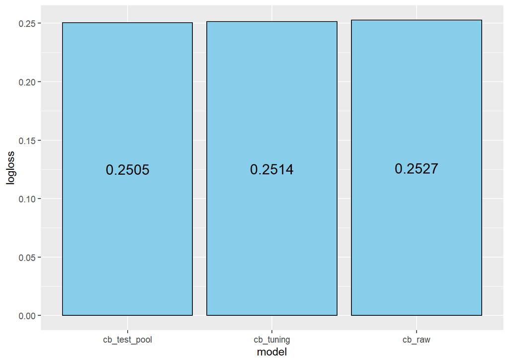

```r
result <- tibble('model' = c('cb_raw', 'cb_tuning', 'cb_test_pool'),
                 'logloss' = c(result_cb, result_cb_2, result_cb_3))

result %>% ggplot(aes(x = reorder(model, logloss), y = logloss)) +
  geom_col(color = 'black', fill = 'skyblue') +
  geom_text(aes(label = round(logloss, 4)), position = position_stack(0.5), size = 5) +
  labs(x = 'model', y = 'logloss')
```

### 성능도 더 좋게 나온다

## 추가 문제 6

```r
params_gpu <- list(
  loss_function = 'Logloss',
  random_seed = 1,
  logging_level = 'Verbose',
  train_dir = "CatBoost_output",
  iterations = 200,
  max_ctr_complexity = 4,
  bootstrap_type = 'Bayesian',
  learning_rate = 0.1,
  task_type = 'GPU'
)
start = Sys.time()
model_cb_gpu <- catboost.train(learn_pool = train_pool,
                               params = params_gpu); end = Sys.time() ; cb_gpu_time = end - start
```

```
## 0:   learn: 0.5810849    total: 45ms remaining: 8.96s
## 1:   learn: 0.4991436    total: 91.5ms   remaining: 9.06s
## 2:   learn: 0.4363186    total: 139ms    remaining: 9.1s
## 3:   learn: 0.3961950    total: 178ms    remaining: 8.73s
## 4:   learn: 0.3609533    total: 223ms    remaining: 8.71s
## 5:   learn: 0.3353039    total: 264ms    remaining: 8.52s
## 6:   learn: 0.3191450    total: 307ms    remaining: 8.48s
## 7:   learn: 0.3036470    total: 341ms    remaining: 8.17s
## 8:   learn: 0.2916413    total: 381ms    remaining: 8.08s
## 9:   learn: 0.2824480    total: 419ms    remaining: 7.97s
## 10:  learn: 0.2761750    total: 451ms    remaining: 7.75s
## 11:  learn: 0.2708690    total: 491ms    remaining: 7.69s
## 12:  learn: 0.2670126    total: 530ms    remaining: 7.62s
## 13:  learn: 0.2637808    total: 572ms    remaining: 7.61s
## 14:  learn: 0.2606768    total: 615ms    remaining: 7.59s
```

[output cut: 185 more lines]

## 추가 문제 6-1

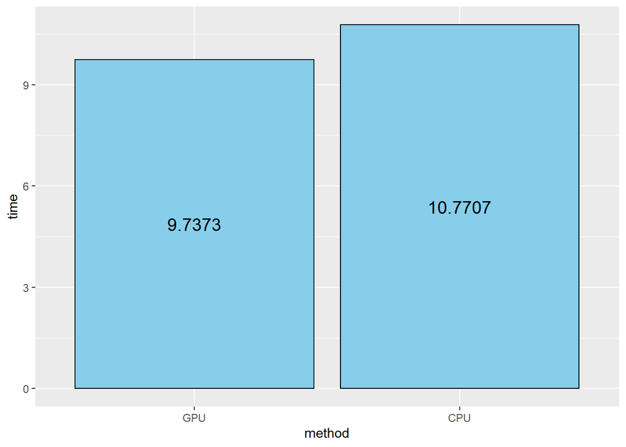

```r
time_check <- tibble('method' = c('CPU', 'GPU'),
                     'time' = c(as.numeric(cb_cpu_time), as.numeric(cb_gpu_time)))

time_check %>% ggplot(aes(x = reorder(method, time), y = time)) +
  geom_col(color = 'black', fill = 'skyblue') +
  geom_text(aes(label=round(time, 4)), position = position_stack(0.5), size = 5) +
  labs(x = 'method', y = 'time')
```

### 조금 빨라짐!!

## 추가 문제 6-2

```r
predict_cb_gpu <- catboost.predict(model_cb_gpu, test_pool, prediction_type = 'Probability')
result_cb_gpu <- LogLoss(predict_cb_gpu, real_click) ; result_cb_gpu
```

```
## [1] 0.251045
```

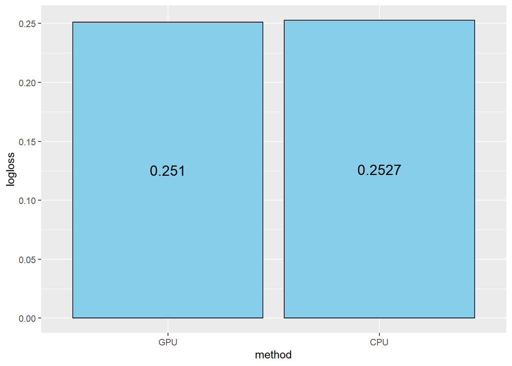

```r
result <- tibble('method' = c('CPU', 'GPU'),
                 'logloss' = c(result_cb, result_cb_gpu))

result %>% ggplot(aes(x = reorder(method, logloss), y = logloss)) +
  geom_col(color = 'black', fill = 'skyblue') +
  geom_text(aes(label = round(logloss, 4)), position = position_stack(0.5), size = 5) +
  labs(x = 'method', y = 'logloss')
```

### 조금 좋아짐

## 추가 문제 6-3

```r
object.size(model_cb)
```

```
## 370376 bytes
```

```r
object.size(model_cb_gpu)
```

```
## 6459528 bytes
```

```r
object.size(model_cb_gpu) - object.size(model_cb)
```

```
## 6089152 bytes
```

### 사이즈는 더 커짐